# Predikcija skupih nekretnina za izdavanje

Naive Bayes klasifikacija sa optimizacijom praga odluke preko ROC krive

Bogdan Stojiljković

2026-09-22

## Uvod

Ovaj projekat je vežba klasifikacije na `rent.csv` skupu podataka ([Kaggle: House Rent Prediction Dataset](https://www.kaggle.com/datasets/iamsouravbanerjee/house-rent-prediction-dataset)) — oglasi za izdavanje stanova u šest indijskih gradova. Cilj je binarna klasifikacija: da li konkretna nekretnina, na osnovu svojih karakteristika (grad, površina, broj soba i kupatila, opremljenost, preferirani zakupac, tip kontakta), spada u gornjih 15% po ceni kirije na tom tržištu (“high rent”) ili ne.

Fokus projekta je metodološki — kompletan tok od čišćenja podataka, preko Naive Bayes klasifikacije sa diskretizacijom numeričkih promenljivih, do ROC analize i optimizacije praga odluke prema Youden-ovom kriterijumu. Isti pristup (klasifikacija “premium” segmenta na osnovu strukturnih karakteristika, bez oslanjanja na tačnu cenu) bi realno mogao poslužiti platformi za izdavanje nekretnina za automatsko tagovanje oglasa ili kao signal za proveru oglasa čija cena ne odgovara očekivanjima za date karakteristike.

## Podaci i čišćenje

```r
data <- load_and_clean_rent_data(here::here("data", "rent.csv"))
str(data)
```

```
## 'data.frame':    4743 obs. of  8 variables:
##  $ BHK              : int  2 2 2 2 2 2 2 1 2 2 ...
##  $ Size             : num  1100 800 1000 800 850 600 700 250 800 1000 ...
##  $ City             : Factor w/ 6 levels "Bangalore","Chennai",..: 5 5 5 5 5 5 5 5 5 5 ...
##  $ Furnishing.Status: Factor w/ 3 levels "Furnished","Semi-Furnished",..: 3 2 2 3 3 3 3 3 3 2 ...
##  $ Tenant.Preferred : Factor w/ 3 levels "Bachelors","Bachelors/Family",..: 2 2 2 2 1 2 1 1 1 2 ...
##  $ Bathroom         : int  2 1 1 1 1 2 2 1 2 2 ...
##  $ Point.of.Contact : Factor w/ 3 levels "Contact Agent",..: 3 3 3 3 3 3 1 1 1 3 ...
##  $ High_Rent        : Factor w/ 2 levels "no","yes": 1 1 1 1 1 1 1 1 1 1 ...
```

Originalni skup ima 4746 oglasa. Nakon uklanjanja redova sa nedostajućom vrednošću `Rent` (koja se koristi za kreiranje izlazne promenljive, pa se ne imputira), ostaje 4743 opservacija. Izlazna promenljiva `High_Rent` je definisana kao `yes` za kirije iznad 85. percentila:

```r
table(data$High_Rent)
```

```
##
##   no  yes
## 4040  703
```

```r
prop.table(table(data$High_Rent))
```

```
##
##        no       yes
## 0.8517816 0.1482184
```

Klasa `yes` čini oko 15% podataka — ovo je namerno neuravnotežen problem, i to je glavni razlog zašto se kasnije posebno razmatra prag odluke umesto podrazumevanog 0.5.

Tri promenljive (`Posted.On`, `Floor`, `Area.Locality`) su uklonjene jer imaju previše različitih vrednosti da bi bile korisne kao kategorički prediktori (81, 480 i 2234 nivoa). Nedostajuće vrednosti za `City` (moda) i `Size` (medijana, jer Shapiro-Wilk test odbacuje normalnost) su imputirane.

## Eksplorativna analiza

Za svaku preostalu promenljivu proverena je da li postoji vidljiva razlika u raspodeli između `high rent` i `low rent` nekretnina — to je i osnova za odluku da se sve promenljive zadrže u modelu.

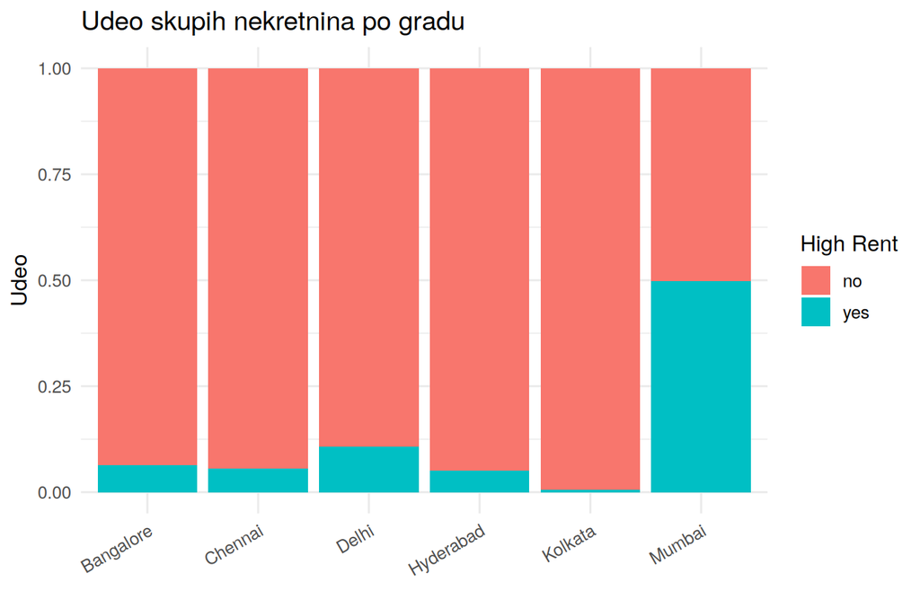

```r
plots <- generate_eda_plots(data)
save_eda_plots(plots, here::here("figures"))

plots$city
```

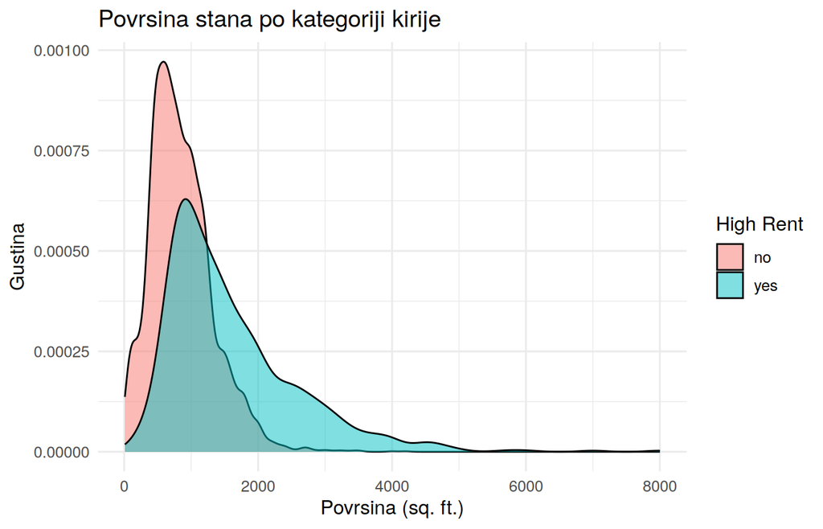

```r
plots$size
```

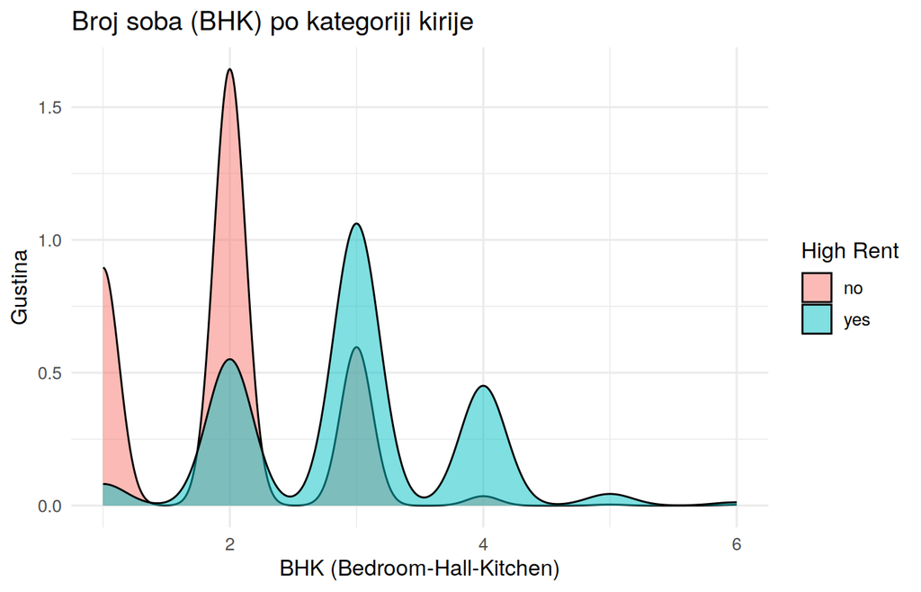

```r
plots$bhk
```

Grad je posebno izražen prediktor — dok u pet od šest gradova skupe nekretnine čine ispod 12% oglasa, u Mumbaiju je taj udeo blizu 50%. Veća površina i veći broj soba takođe jasno pomeraju verovatnoću ka “high rent” klasi. (Ostali grafici — broj kupatila, opremljenost, preferirani zakupac, tip kontakta — sačuvani su u `figures/` folderu.)

## Priprema za Naive Bayes

Naive Bayes u ovoj implementaciji tretira numeričke prediktore kao kontinuirane (pod pretpostavkom normalne raspodele) ili kao diskretne kategorije. Pošto `BHK`, `Size` i `Bathroom` nemaju normalnu raspodelu, diskretizovane su na intervale jednake frekvencije (2, 5 i 2 intervala redom — manji broj za `BHK`/`Bathroom` jer imaju malo različitih celobrojnih vrednosti).

```r
split <- split_train_test(data, p = 0.8, seed = 1010)
train <- prepare_for_naive_bayes(split$train)
test  <- prepare_for_naive_bayes(split$test)

str(train)
```

```
## 'data.frame':    3795 obs. of  8 variables:
##  $ BHK              : Factor w/ 2 levels "[1,2]","(2,6]": 1 1 1 1 1 1 2 1 1 2 ...
##  $ Size             : Factor w/ 5 levels "[20,500]","(500,710]",..: 3 3 3 2 2 3 4 1 1 4 ...
##  $ Bathroom         : Factor w/ 2 levels "[1,2]","(2,10]": 1 1 1 1 1 1 1 1 1 1 ...
##  $ City             : Factor w/ 6 levels "Bangalore","Chennai",..: 5 5 5 5 5 5 5 5 5 5 ...
##  $ Furnishing.Status: Factor w/ 3 levels "Furnished","Semi-Furnished",..: 2 3 3 3 3 2 2 1 3 1 ...
##  $ Tenant.Preferred : Factor w/ 3 levels "Bachelors","Bachelors/Family",..: 2 2 1 2 1 2 2 1 2 2 ...
##  $ Point.of.Contact : Factor w/ 3 levels "Contact Agent",..: 3 3 3 3 1 3 1 3 1 3 ...
##  $ High_Rent        : Factor w/ 2 levels "no","yes": 1 1 1 1 1 1 1 1 1 1 ...
```

## Model i osnovna evaluacija

```r
model <- train_naive_bayes(train)

pred_default <- predict_with_threshold(model, test, threshold = 0.5)
cm_default <- table(true = test$High_Rent, predicted = pred_default)
cm_default
```

```
##      predicted
## true   no yes
##   no  799   9
##   yes  63  77
```

```r
metrics_default <- get_evaluation_metrics(cm_default)
round(metrics_default, 3)
```

```
##  Accuracy Precision    Recall        F1
##     0.924     0.895     0.550     0.681
```

Sa podrazumevanim pragom od 0.5, model ima visok **precision** (0.895) ali osetno niži **recall** (0.55) — kada model kaže da je nekretnina skupa, gotovo uvek je u pravu, ali propušta znatan broj stvarno skupih nekretnina jer je klasa manjinska.

## ROC kriva i optimizacija praga

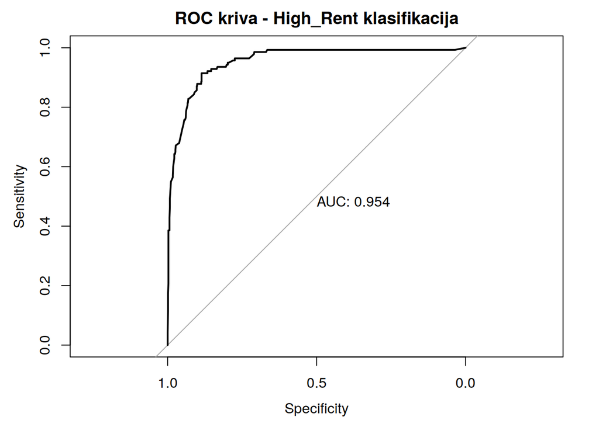

```r
roc_obj <- compute_roc(model, test)
plot.roc(roc_obj, print.auc = TRUE, main = "ROC kriva - High_Rent klasifikacija")
```

```r
auc_value <- as.numeric(roc_obj$auc)
```

AUC vrednost je 0.954, što se smatra veoma dobrim rezultatom (AUC > 0.9). To znači da model, nezavisno od izabranog praga, vrlo dobro razdvaja skupe od jeftinijih nekretnina — pitanje je samo gde postaviti granicu.

Youden-ov kriterijum bira prag koji maksimizuje zbir specificity i sensitivity:

```r
best_threshold <- find_youden_threshold(roc_obj)
best_threshold
```

```
## [1] 0.08509853
```

```r
pred_tuned <- predict_with_threshold(model, test, threshold = best_threshold)
cm_tuned <- table(true = test$High_Rent, predicted = pred_tuned)
cm_tuned
```

```
##      predicted
## true   no yes
##   no  716  92
##   yes  12 128
```

```r
metrics_tuned <- get_evaluation_metrics(cm_tuned)
round(metrics_tuned, 3)
```

```
##  Accuracy Precision    Recall        F1
##     0.890     0.582     0.914     0.711
```

## Poređenje: podrazumevani vs. optimizovani prag

```r
comparison <- data.frame(
  rbind(metrics_default, metrics_tuned),
  row.names = c("threshold = 0.5", paste0("threshold = ", round(best_threshold, 3)))
)
round(comparison, 3)
```

```
##                   Accuracy Precision Recall    F1
## threshold = 0.5      0.924     0.895  0.550 0.681
## threshold = 0.085    0.890     0.582  0.914 0.711
```

Ovo je i suština priče projekta: pomeranjem praga sa 0.5 na 0.085, recall skače sa 55% na 91.4%, ali precision pada sa 89.5% na 58.2%. Koji prag je “bolji” zavisi od primene:

- ako je cilj **ne propustiti nijedan potencijalno skup oglas** (npr. za ručnu proveru ili prioritetno oglašavanje), prag treba pomeriti ka nižim vrednostima — veći recall, manje precision;
- ako je cilj **filter u kome se korisniku pokazuje samo ono za šta smo sigurni da je premium segment**, podrazumevani prag je bolji izbor — veći precision.

## Zaključak i ograničenja

Model postiže visok AUC (0.954) i jasno pokazuje da struktura nekretnine (pre svega grad, površina i broj soba) nosi dovoljno informacije da se predvidi cenovni segment bez poznavanja tačne cene. Prag od 85. percentila za definisanje “high rent” klase je izbor napravljen za potrebe ove vežbe; u realnoj primeni bi verovatno bio prilagođen poslovnom kontekstu (npr. po gradu posebno, s obzirom na to koliko se tržišta gradova razlikuju). Takođe, model je treniran na podacima iz 2022. godine za šest konkretnih gradova, pa se rezultati ne mogu generalizovati van tog konteksta bez ponovnog treniranja.